# Produkcia piva

Dáta v súbore pivo.dat predstavujú produkciu piva v miliónoch litrov v Austrálii v období január 1958- december 1990

### Načítanie dát

```r
pivo <- read.csv2("pivo.dat", sep="")
str(pivo)
```

```
## 'data.frame':    396 obs. of  1 variable:
##  $ beer: num  96.3 84.4 91.2 81.9 80.5 70.4 74.8 75.9 86.3 98.7 ...
```

```r
beer<-pivo$beer
```

### Zobrazenie ČR

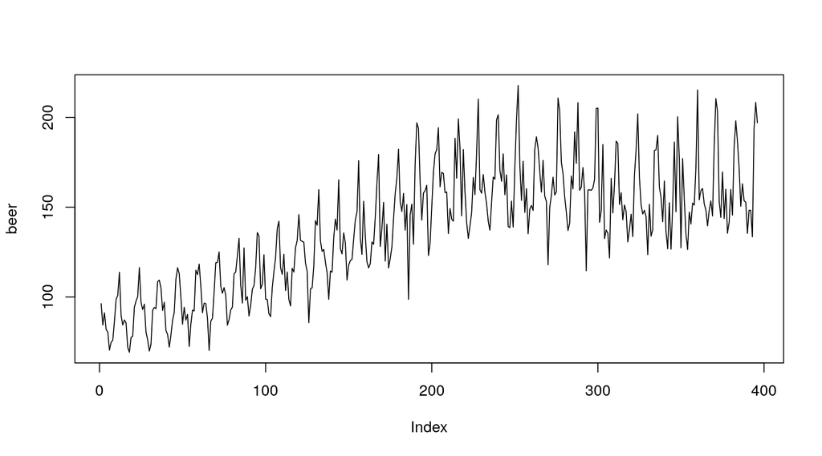

```r
plot(beer, type="l")
```

Pozorujeme, že s trendom narastá variabilita, v takých prípadoch je vhodná **logaritmická transformácia**. Tá sa často používa, lebo sa dá ľahko interpretovať. Konkrétne, ak dôjde k prírastku v dátach o 1:

$$1 = \log{y_1} - \log{y_2} = \log{\frac{y_1}{y_2}}$$

Z aditivity modelu vieme, že

$$X_t = \mu_t + S_t + \varepsilon_t$$

V ekonomických (a i.) dátach je často výhodnejšie použiť iný model - tzv. multiplikatívny model:

$$X_t = \mu_tS_t\varepsilon_t$$

Logaritmickou transformáciou sa však vieme dostať od multiplikatívnemu modelu dostať k aditívnemu:

$$\log{X_t} = log{\mu_t} + \log{S_t} + \log{\varepsilon_t}$$
.

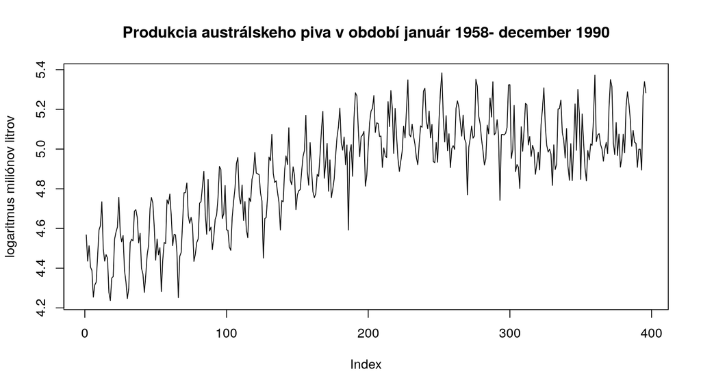

```r
lbeer<-log(beer)
plot(lbeer, type="l", main = "Produkcia austrálskeho piva v období január 1958- december 1990", ylab="logaritmus miliónov litrov")
```

### Pozorovanie

- trend
- sezónna zložka (ekonomický ČR - predpokladáme periódu 12)
- variabilita po logaritmovaní ustálená

### Odstránenie trendu lineárnou regresiou

z princípu úspornosti sa núka ako najjednoduchší kvadratický trend. Predpokladáme teda rovnicu v tvare:
$$\mathrm{ln}(X_t)=a_0+a_1t+a_2t^2+s_t+Y_t$$

### Úloha

**Znázornite logaritmované dáta spolu s odhadnutým kvadratickým trendom a zistite koeficienty kvadratického trendu.**

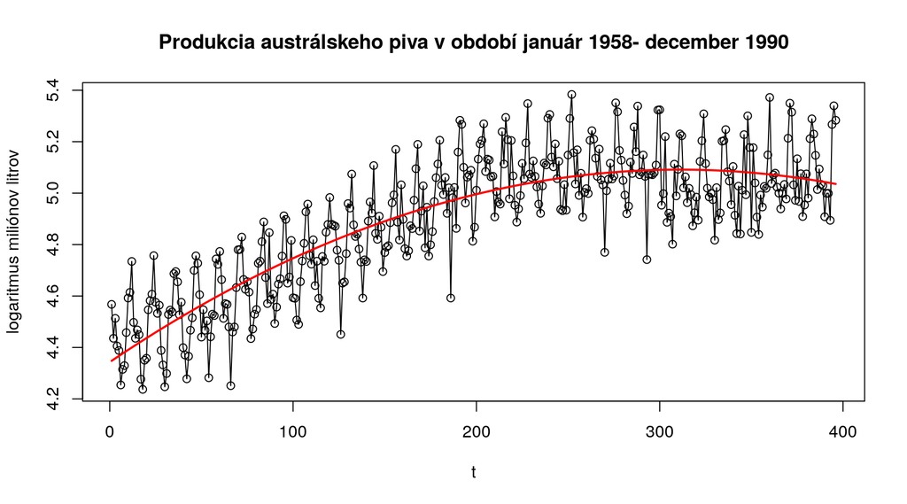

```r
t<-1:length(beer)
t2<-t*t
trend<-lm(lbeer~t+t2)
plot(t,lbeer, type="o", main = "Produkcia austrálskeho piva v období január 1958- december 1990", ylab="logaritmus miliónov litrov")
lines(t,predict(trend), col="red", lwd=2)
```

```r
coefficients(trend)
```

```
##   (Intercept)             t            t2
##  4.343111e+00  4.809381e-03 -7.728940e-06
```

### Úloha

**Znázornite reziduá po kvadratickom trende.**

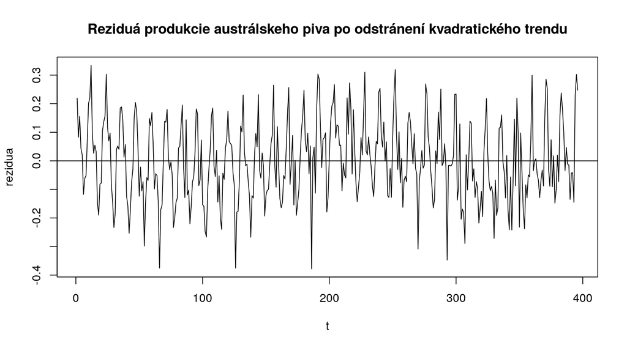

```r
rezidua<-residuals(trend)
plot(t,rezidua, type="l", main = "Reziduá produkcie austrálskeho piva po odstránení kvadratického trendu")
abline(0,0)
```

Očakávame, že perióda sezónnej zložky bude 12, takže budeme uvažovať sezónnu zložku v tvare z prednášky:
$$S_t = \beta\cos{\frac{2\pi}{12}t}+\gamma\sin{\frac{2\pi}{12}t}$$

Nadefinujeme si premenné pre sínus a kosínus. Tento model sa nazýva aj harmonická regresia.

[figure not shown]

```r
sint = sin(2*pi*t/12)
cost = cos(2*pi*t/12)
trendSes <- lm(lbeer~t+t2+sint+cost)
plot(t,lbeer, type="o", main = "Produkcia austrálskeho piva v období január 1958- december 1990", ylab="logaritmus miliónov litrov")
lines(t,predict(trendSes), col="red", lwd=2)
```

```r
coefficients(trendSes)
```

```
##   (Intercept)             t            t2          sint          cost
##  4.344227e+00  4.805692e-03 -7.736248e-06 -7.220123e-03  1.452867e-01
```

## Znázornenie reziduí po po odstránení sezónnej zložky

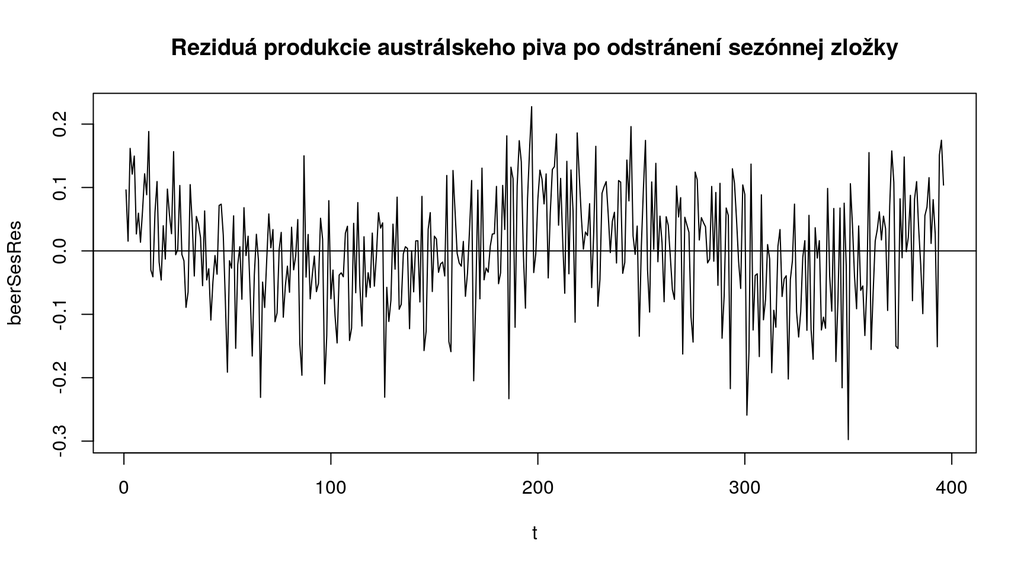

```r
beerSesRes <- residuals(trendSes)
plot(t,beerSesRes, type="l", main = "Reziduá produkcie austrálskeho piva po odstránení sezónnej zložky")
abline(0,0)
```

V dátach ešte stále vidíme nejakú periodickú zložku. Takže ešte tam zrejme bude prítomná nejaká významná frekvencia, ktorú budeme vedieť odhaliť pomocou periódogramu.